# Predicting Activity Types Based on Activity Tracker Data

Karl Hartwig

22 juni 2018

## Introduction

Today activity monitoring devices such as Jawbone Up, Nike FuelBand, and Fitbit are becomming more and more popular. This work seeks to build a predictive model to identify how well a person is performing dumbbell lifts based on provided accelerometer data collected by such devices.

When comparing the results of five different forecasting methods this work found that Random Forest (RF) had the best performance.

## Description of the dataset

The devices were placed on the belt, forearm, arm, and barbell of 6 participants performing dumbbell biceps curls in five different ways:

- Class A, exactly according to the specification,
- Class B, throwing the elbows to the front,
- Class C, lifting the dumbbell only halfway,
- Class D, lowering the dumbbell only halfway,
- Class E, throwing the hips to the front (Class E).

More information about the utilised Weight Lifting Exercises Dataset and background data can be found at: http://web.archive.org/web/20161224072740/http:/groupware.les.inf.puc-rio.br/har

The original research based on the data can be studied in the following paper:

*Velloso, E.; Bulling, A.; Gellersen, H.; Ugulino, W.; Fuks, H. Qualitative Activity Recognition of Weight Lifting Exercises. Proceedings of 4th International Conference in Cooperation with SIGCHI (Augmented Human ’13) . Stuttgart, Germany: ACM SIGCHI, 2013.*

## Set up R environment

```r
# load required packages
library(caret)
library(dplyr)
library(gbm)
library(rpart)
library(randomForest)
library(RANN)
library(rattle)
library(corrplot)
library(knitr)
library(parallel)
library(doParallel)

# set up parallel clusters for faster processing (leave 1 core for OS)
cluster <- makeCluster(detectCores() - 1)
registerDoParallel(cluster)
```

## Preparing Data

### Download Data and Create Validation Set

The test and training dataset were downloaded. and the training set split into a train and validation dataset. The two latter contained 70% and 30% of the downloaded training set in order to enable estimation of out of sample error later in the analyses.

```r
# Set up dataset URLs
trainUrl <- "https://d396qusza40orc.cloudfront.net/predmachlearn/pml-training.csv"
testUrl <- "https://d396qusza40orc.cloudfront.net/predmachlearn/pml-testing.csv"

# Download Data
trainIn <- read.csv(trainUrl, na.strings=c("NA","#DIV/0!",""))
testIn <- read.csv(testUrl, na.strings=c("NA","#DIV/0!",""))

# create cross validation sets i.e. pratition trainingset into two for
# validation of fitted models without using test set
idTrain<-createDataPartition(y=trainIn$classe,p=0.70,list=FALSE)
trainSub<-trainIn[idTrain,]
validation<-trainIn[-idTrain,]
```

### Data Cleaning

```r
# Remove NearZeroVariance variables
Nzv<-nearZeroVar(trainSub, saveMetrics=TRUE)
NzvIdx<-colnames(trainSub) %in% rownames(Nzv[Nzv$nzv|Nzv$zeroVar,])
TrainUse<-trainSub[,!NzvIdx]
ValidationUse<-validation[,!NzvIdx]

# Remove columns associated with subject id and name and time
TrainUse<-TrainUse[,-c(1:6)]
ValidationUse<-ValidationUse[,-c(1:6)]

# find percentage of missing values in each column
nNa<-sapply(1:ncol(TrainUse),function(i)sum(is.na(TrainUse[,i]))/nrow(TrainUse))

# remove columns that has more than 90% missing values
removeCol<-nNa>0.9
TrainUse<-TrainUse[,!removeCol]

# cleaning data:
# -standardising variables, (value-mean)/std
preObj<-preProcess(TrainUse,method=c("center","scale"))

# apply preprocessing
TrainClean<-predict(preObj,TrainUse)

# apply scaling from preprocessing to validation set
ValidationClean<-predict(preObj,ValidationUse)
```

## Exploratory Analysis

Before building predictive models the correlation between predictive variables were explored through a correlation matrix plot.

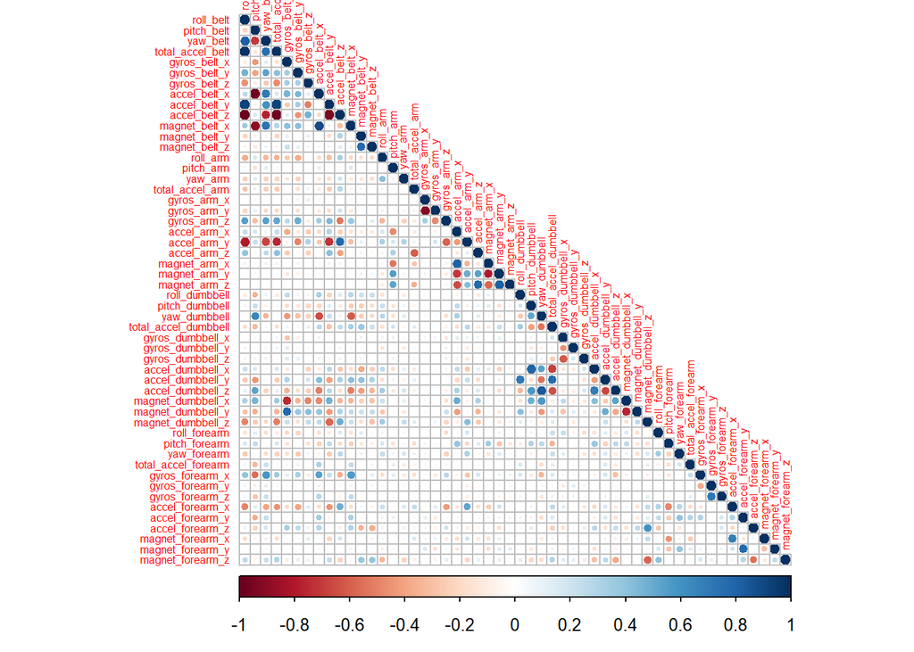

```r
# remove classe from dataset
corMatrix <- cor(TrainClean %>% select(-classe))
corrplot(corMatrix, type = "lower",tl.cex = 0.5)
```

As can be seen in the plot above, relatively few variables are highly correlated. Hence it is not deemed that Principal Components Analysis is required to reduce the dimensions of the dataset.

## Creating Predictive Models

In order to find what model are best suitable for predicting the activity classes the following methods where evaluted.

- Classification Tree via Recurrsive Partitioning (PT),
- Linear Decriminate Analysis (LDA),
- Generalized Boosted Regression (GBM),
- Bagging (BAG),
- Random Forest (RF).

As can be seen in Table 1 in Appendix A5 below, the RF method outperformed all other investigated methods. Due to this the RF model is applied to the supplied test set in later sections of this document and will be the focus of the rest of this work. The detailed results of the other models can be found in Appendix A.

## Evaluation of the Chosen Random Forest Model

The chosen RF model was trained through a five-fold cross validation applied to the pre-processed dataset. Parallel processing was enabled in order to speed up training.

```r
#set seed
set.seed(3211)

#apply 5 fold cross validation
control <- trainControl(method="cv", number = 5,
                           allowParallel = TRUE)
```

### Evaluating In-Sample Error

As can be seen in the print out below the mean in-sample training error for the random forest is just above one percent.

```r
# Fit classification Tree through Bagging
modRF<-train(classe ~ .,method="rf",data=TrainClean,preProcess=c("scale","center" ),prox=TRUE, trControl=control)

# Show model summary
modRF
```

```
## Random Forest
##
## 13737 samples
##    52 predictor
##     5 classes: 'A', 'B', 'C', 'D', 'E'
##
## Pre-processing: scaled (52), centered (52)
## Resampling: Cross-Validated (5 fold)
## Summary of sample sizes: 10988, 10991, 10989, 10991, 10989
## Resampling results across tuning parameters:
##
##   mtry  Accuracy   Kappa
##    2    0.9912640  0.9889485
##   27    0.9907548  0.9883037
##   52    0.9859502  0.9822242
##
## Accuracy was used to select the optimal model using the largest value.
## The final value used for the model was mtry = 2.
```

The in sample errors increase slightly with the number of applied predictors as seen in the figur below. Yet it remains remains fairly stable.

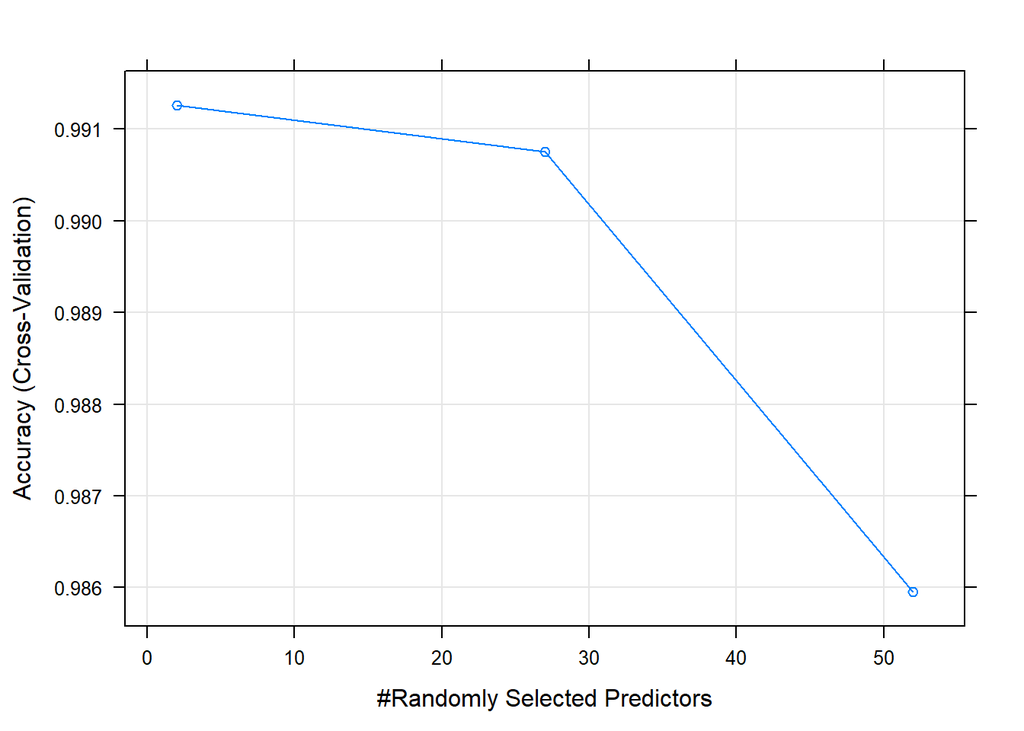

```r
plot(modRF)
```

As expeted the error rate drops rapidly as the number of trees in the random forest increase. This is however mostly noticable as the number of trees grows from one to about 40. After this the rate stays fairly constant and is only marginally improved as the number of trees goes from 100 to 500.

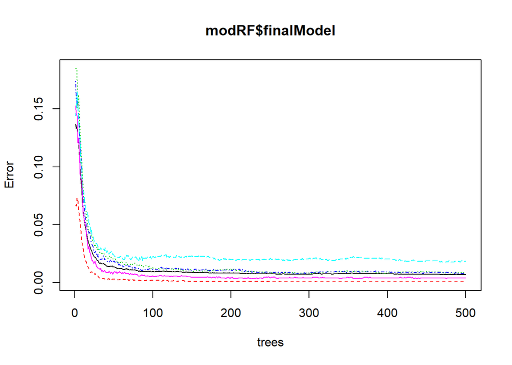

```r
plot(modRF$finalModel)
```

### Evaluating Out of Sample Error

```r
# apply predictive model
predRF<-predict(modRF,ValidationClean)

# look at error matrix
RFMat<-confusionMatrix(ValidationClean$classe, predRF)
RFMat
```

```
## Confusion Matrix and Statistics
##
##           Reference
## Prediction    A    B    C    D    E
##          A 1674    0    0    0    0
##          B    2 1137    0    0    0
##          C    0    0 1024    2    0
##          D    0    0    6  958    0
##          E    0    0    2    3 1077
##
## Overall Statistics
##
##                Accuracy : 0.9975
##                  95% CI : (0.9958, 0.9986)
##     No Information Rate : 0.2848
##     P-Value [Acc > NIR] : < 2.2e-16
##
##                   Kappa : 0.9968
##  Mcnemar's Test P-Value : NA
##
## Statistics by Class:
##
##                      Class: A Class: B Class: C Class: D Class: E
## Sensitivity            0.9988   1.0000   0.9922   0.9948   1.0000
## Specificity            1.0000   0.9996   0.9996   0.9988   0.9990
## Pos Pred Value         1.0000   0.9982   0.9981   0.9938   0.9954
## Neg Pred Value         0.9995   1.0000   0.9984   0.9990   1.0000
## Prevalence             0.2848   0.1932   0.1754   0.1636   0.1830
## Detection Rate         0.2845   0.1932   0.1740   0.1628   0.1830
## Detection Prevalence   0.2845   0.1935   0.1743   0.1638   0.1839
## Balanced Accuracy      0.9994   0.9998   0.9959   0.9968   0.9995
```

```r
# calculate out of sample accuracy
OutSampleAccRF<-RFMat$overall["Accuracy"]

# Calculate In Sample Accuracy
InSampleAccRF<-mean(modRF$results["Accuracy"]["Accuracy"][,1])
```

## Application of Final Model on Test Set

Finally, the model was applied to the test set to predict the type of activities performed as displayed below.

```r
# apply scaling to test set
Test<-predict(preObj,testIn)

# apply predictive model
predRFTest<-predict(modRF,Test)

outcome<-paste(predRFTest,collapse=", ")
```

The predicted classifications of the provided test set are B, A, B, A, A, E, D, B, A, A, B, C, B, A, E, E, A, B, B, B.

## Conclusion

In this work five different predictive algorithms were applied to a dataset containing correct and incorrect movements of people conducting dumbbell biceps curls. Of the investigated algorithms Random Forest performed best. This is attributed to the way random forests randomly drops predicitive variable during training in different trees. This makes the forest as a whole less dependant on one single, or a few, predictive variables which in turn makes the algorithm robust to correlated covariates and outliers in general.

## Appendix A: other tested models

### A1: Classification Tree via Recurrsive Partitioning

[figure not shown]

```r
# Fit classification Tree
modTree<-train(classe ~ .,method="rpart",data=TrainClean,preProcess=c("scale","center" ), trControl=control)
fancyRpartPlot(modTree$finalModel)
```

```r
# apply predictive model
predTree<-predict(modTree,ValidationClean)

# Check out of sample error
TreeMat<-confusionMatrix(ValidationClean$classe, predTree)
TreeMat
```

```
## Confusion Matrix and Statistics
##
##           Reference
## Prediction    A    B    C    D    E
##          A 1495   33  120    0   26
##          B  467  392  280    0    0
##          C  480   37  509    0    0
##          D  414  175  375    0    0
##          E  141  146  279    0  516
##
## Overall Statistics
##
##                Accuracy : 0.4948
##                  95% CI : (0.482, 0.5077)
##     No Information Rate : 0.5093
##     P-Value [Acc > NIR] : 0.9871
##
##                   Kappa : 0.3406
##  Mcnemar's Test P-Value : NA
##
## Statistics by Class:
##
##                      Class: A Class: B Class: C Class: D Class: E
## Sensitivity            0.4988  0.50064  0.32566       NA  0.95203
## Specificity            0.9380  0.85359  0.88038   0.8362  0.89407
## Pos Pred Value         0.8931  0.34416  0.49610       NA  0.47689
## Neg Pred Value         0.6433  0.91761  0.78308       NA  0.99459
## Prevalence             0.5093  0.13305  0.26559   0.0000  0.09210
## Detection Rate         0.2540  0.06661  0.08649   0.0000  0.08768
## Detection Prevalence   0.2845  0.19354  0.17434   0.1638  0.18386
## Balanced Accuracy      0.7184  0.67711  0.60302       NA  0.92305
```

### A2: Bagging

```r
# Fit model
modBag<-train(classe ~ .,method="treebag",data=TrainClean,preProcess=c("scale","center" ), trControl=control)
modBag$finalModel
```

```
##
## Bagging classification trees with 25 bootstrap replications
```

```r
# apply predictive model
predBag<-predict(modBag,ValidationClean)

# Check out of sample error
bagMat<-confusionMatrix(ValidationClean$classe, predBag)
bagMat
```

```
## Confusion Matrix and Statistics
##
##           Reference
## Prediction    A    B    C    D    E
##          A 1656    9    6    2    1
##          B   16 1109    9    3    2
##          C    1    8 1008    8    1
##          D    3    5   12  940    4
##          E    0    4    6    6 1066
##
## Overall Statistics
##
##                Accuracy : 0.982
##                  95% CI : (0.9783, 0.9852)
##     No Information Rate : 0.2848
##     P-Value [Acc > NIR] : <2e-16
##
##                   Kappa : 0.9772
##  Mcnemar's Test P-Value : 0.2393
##
## Statistics by Class:
##
##                      Class: A Class: B Class: C Class: D Class: E
## Sensitivity            0.9881   0.9771   0.9683   0.9802   0.9926
## Specificity            0.9957   0.9937   0.9963   0.9951   0.9967
## Pos Pred Value         0.9892   0.9737   0.9825   0.9751   0.9852
## Neg Pred Value         0.9953   0.9945   0.9932   0.9961   0.9983
## Prevalence             0.2848   0.1929   0.1769   0.1630   0.1825
## Detection Rate         0.2814   0.1884   0.1713   0.1597   0.1811
## Detection Prevalence   0.2845   0.1935   0.1743   0.1638   0.1839
## Balanced Accuracy      0.9919   0.9854   0.9823   0.9877   0.9946
```

### A3: Generalized Boosted Regression

```r
# Fit Generalised boosted regression
modGbm<-train(classe ~ .,method="gbm",data=TrainClean,preProcess=c("scale","center" ),verbose=FALSE, trControl=control)

# apply predictive model
predGbm<-predict(modGbm,ValidationClean)

# Check out of sample error
GbmMat<-confusionMatrix(ValidationClean$classe, predGbm)
GbmMat
```

```
## Confusion Matrix and Statistics
##
##           Reference
## Prediction    A    B    C    D    E
##          A 1637   28    4    2    3
##          B   50 1064   25    0    0
##          C    0   38  975   12    1
##          D    0    2   29  930    3
##          E    1   11   13   17 1040
##
## Overall Statistics
##
##                Accuracy : 0.9594
##                  95% CI : (0.954, 0.9643)
##     No Information Rate : 0.2868
##     P-Value [Acc > NIR] : < 2.2e-16
##
##                   Kappa : 0.9486
##  Mcnemar's Test P-Value : 2.033e-08
##
## Statistics by Class:
##
##                      Class: A Class: B Class: C Class: D Class: E
## Sensitivity            0.9698   0.9309   0.9321   0.9677   0.9933
## Specificity            0.9912   0.9842   0.9895   0.9931   0.9913
## Pos Pred Value         0.9779   0.9342   0.9503   0.9647   0.9612
## Neg Pred Value         0.9879   0.9834   0.9854   0.9937   0.9985
## Prevalence             0.2868   0.1942   0.1777   0.1633   0.1779
## Detection Rate         0.2782   0.1808   0.1657   0.1580   0.1767
## Detection Prevalence   0.2845   0.1935   0.1743   0.1638   0.1839
## Balanced Accuracy      0.9805   0.9575   0.9608   0.9804   0.9923
```

### A4: Linear Decriminate Analysis

```r
# Fit linear decriminate analysis model
modLda<-train(classe ~ .,method="lda",data=TrainClean,preProcess=c("scale","center" ),varbose=FALSE, trControl=control)

# apply predictive model
PredLda<-predict(modLda,ValidationClean)

# Check out of sample error
LdaMat<-confusionMatrix(ValidationClean$classe, PredLda)
LdaMat
```

```
## Confusion Matrix and Statistics
##
##           Reference
## Prediction    A    B    C    D    E
##          A 1337   33  156  141    7
##          B  160  740  144   43   52
##          C   93   87  696  124   26
##          D   64   40  123  705   32
##          E   45  180   79  105  673
##
## Overall Statistics
##
##                Accuracy : 0.7054
##                  95% CI : (0.6935, 0.717)
##     No Information Rate : 0.2887
##     P-Value [Acc > NIR] : < 2.2e-16
##
##                   Kappa : 0.6275
##  Mcnemar's Test P-Value : < 2.2e-16
##
## Statistics by Class:
##
##                      Class: A Class: B Class: C Class: D Class: E
## Sensitivity            0.7869   0.6852   0.5810   0.6306   0.8519
## Specificity            0.9195   0.9170   0.9296   0.9457   0.9197
## Pos Pred Value         0.7987   0.6497   0.6784   0.7313   0.6220
## Neg Pred Value         0.9140   0.9284   0.8967   0.9161   0.9756
## Prevalence             0.2887   0.1835   0.2036   0.1900   0.1342
## Detection Rate         0.2272   0.1257   0.1183   0.1198   0.1144
## Detection Prevalence   0.2845   0.1935   0.1743   0.1638   0.1839
## Balanced Accuracy      0.8532   0.8011   0.7553   0.7881   0.8858
```

### A5: Create Summary Table

```r
# calculate out of sample accuracy
OutSampleAccTree<-TreeMat$overall["Accuracy"]
OutSampleAccLda<-LdaMat$overall["Accuracy"]
OutSampleAccGbm<-GbmMat$overall["Accuracy"]
OutSampleAccBag<-bagMat$overall["Accuracy"]

# Calculate In Sample Accuracy
InSampleAccTree<-mean(modTree$results["Accuracy"]["Accuracy"][,1])
InSampleAccLda<-mean(modLda$results["Accuracy"]["Accuracy"][,1])
InSampleAccGbm<-mean(modGbm$results["Accuracy"]["Accuracy"][,1])
InSampleAccBag<-mean(modBag$results["Accuracy"]["Accuracy"][,1])

# Create Table and round to 3 decimals
Model<-c("PT","LDA","GBM", "BAG", "RF")
Out.Of.Sample.Acc<-round(
      c(OutSampleAccTree, OutSampleAccLda, OutSampleAccGbm, OutSampleAccBag, OutSampleAccRF),
      3)
In.Sample.Acc<-round(
      c(InSampleAccTree, InSampleAccLda, InSampleAccGbm, InSampleAccBag, InSampleAccRF),
      3)

# Combine data to form summary table
Summary<-data.frame(Model,In.Sample.Acc,Out.Of.Sample.Acc)
Summary["Out.Of.Sample.Err"]<-1-Out.Of.Sample.Acc
Summary["In.Sample.Err"]<-1-In.Sample.Acc
Table1<-kable(Summary,  caption = "Table 1: Accuracy and Errors all Prediction Methods",booktabs = TRUE)

Table1
```

Table 1: Accuracy and Errors all Prediction Methods

| Model | In.Sample.Acc | Out.Of.Sample.Acc | Out.Of.Sample.Err | In.Sample.Err |
| --- | --- | --- | --- | --- |
| PT | 0.410 | 0.495 | 0.505 | 0.590 |
| LDA | 0.701 | 0.705 | 0.295 | 0.299 |
| GBM | 0.881 | 0.959 | 0.041 | 0.119 |
| BAG | 0.983 | 0.982 | 0.018 | 0.017 |
| RF | 0.989 | 0.997 | 0.003 | 0.011 |

```r
stopCluster(cluster)
registerDoSEQ()
```